# R Notebook

```r
library(ggplot2)
```

```r
### Read training data
#! Perhaps you need to set the working directory!?
#setwd("/home/pbac/g/course02417/2025/assignment1")
D <- read.csv("DST_BIL54.csv")
str(D)
```

```
'data.frame':   84 obs. of  13 variables:
 $ time        : chr  "2018-01" "2018-02" "2018-03" "2018-04" ...
 $ total       : int  2930483 2934044 2941422 2951498 2963093 2973721 2976096 2985537 2983209 2982473 ...
 $ gasoline    : int  1781826 1783338 1787219 1793554 1799795 1805170 1806338 1810615 1808496 1806710 ...
 $ diesel      : int  1136656 1138414 1141576 1144846 1149840 1154651 1155420 1159907 1159418 1160162 ...
 $ fgas        : int  12 12 12 12 12 12 12 12 11 11 ...
 $ ngas        : int  256 255 257 257 256 262 262 261 261 263 ...
 $ electricity : int  9304 9343 9399 9548 9665 9807 9853 10002 10120 10236 ...
 $ petroleum   : int  0 0 0 0 0 0 0 0 0 0 ...
 $ hydrogen    : int  81 80 77 77 77 77 77 80 82 82 ...
 $ methanol    : int  0 0 0 0 0 0 0 0 0 0 ...
 $ ethanol     : int  0 0 0 0 0 0 0 0 0 0 ...
 $ pluginhybrid: int  2340 2593 2873 3195 3439 3734 4126 4652 4812 5000 ...
 $ otherfuels  : int  8 9 9 9 9 8 8 8 9 9 ...
```

```r
# See the help
?strftime
D$time <- as.POSIXct(paste0(D$time,"-01"), "%Y-%m-%d", tz="UTC")
D$time
```

```
 [1] "2018-01-01 UTC" "2018-02-01 UTC" "2018-03-01 UTC" "2018-04-01 UTC" "2018-05-01 UTC" "2018-06-01 UTC"
 [7] "2018-07-01 UTC" "2018-08-01 UTC" "2018-09-01 UTC" "2018-10-01 UTC" "2018-11-01 UTC" "2018-12-01 UTC"
[13] "2019-01-01 UTC" "2019-02-01 UTC" "2019-03-01 UTC" "2019-04-01 UTC" "2019-05-01 UTC" "2019-06-01 UTC"
[19] "2019-07-01 UTC" "2019-08-01 UTC" "2019-09-01 UTC" "2019-10-01 UTC" "2019-11-01 UTC" "2019-12-01 UTC"
[25] "2020-01-01 UTC" "2020-02-01 UTC" "2020-03-01 UTC" "2020-04-01 UTC" "2020-05-01 UTC" "2020-06-01 UTC"
[31] "2020-07-01 UTC" "2020-08-01 UTC" "2020-09-01 UTC" "2020-10-01 UTC" "2020-11-01 UTC" "2020-12-01 UTC"
[37] "2021-01-01 UTC" "2021-02-01 UTC" "2021-03-01 UTC" "2021-04-01 UTC" "2021-05-01 UTC" "2021-06-01 UTC"
[43] "2021-07-01 UTC" "2021-08-01 UTC" "2021-09-01 UTC" "2021-10-01 UTC" "2021-11-01 UTC" "2021-12-01 UTC"
[49] "2022-01-01 UTC" "2022-02-01 UTC" "2022-03-01 UTC" "2022-04-01 UTC" "2022-05-01 UTC" "2022-06-01 UTC"
[55] "2022-07-01 UTC" "2022-08-01 UTC" "2022-09-01 UTC" "2022-10-01 UTC" "2022-11-01 UTC" "2022-12-01 UTC"
[61] "2023-01-01 UTC" "2023-02-01 UTC" "2023-03-01 UTC" "2023-04-01 UTC" "2023-05-01 UTC" "2023-06-01 UTC"
[67] "2023-07-01 UTC" "2023-08-01 UTC" "2023-09-01 UTC" "2023-10-01 UTC" "2023-11-01 UTC" "2023-12-01 UTC"
[73] "2024-01-01 UTC" "2024-02-01 UTC" "2024-03-01 UTC" "2024-04-01 UTC" "2024-05-01 UTC" "2024-06-01 UTC"
[79] "2024-07-01 UTC" "2024-08-01 UTC" "2024-09-01 UTC" "2024-10-01 UTC" "2024-11-01 UTC" "2024-12-01 UTC"
```

```r
class(D$time)
```

```
[1] "POSIXct" "POSIXt"
```

```r
## Year to month for each of them
D$year <- 1900 + as.POSIXlt(D$time)$year + as.POSIXlt(D$time)$mon / 12

## Make the output variable a floating point (i.e.\ decimal number)
D$total <- as.numeric(D$total) / 1E6

## Divide intro train and test set
teststart <- as.POSIXct("2024-01-01", tz="UTC")
Dtrain <- D[D$time < teststart, ]
Dtest <- D[D$time >= teststart, ]
```

```r
Dtrain
```

|  | time | total | gasoline | diesel | fgas | ngas | electricity | petroleum | hydrogen | methanol | ethanol | pluginhybrid | otherfuels | year |
| --- | --- | --- | --- | --- | --- | --- | --- | --- | --- | --- | --- | --- | --- | --- |
| 1 | 2018-01-01 | 2.930483 | 1781826 | 1136656 | 12 | 256 | 9304 | 0 | 81 | 0 | 0 | 2340 | 8 | 2018.000 |
| 2 | 2018-02-01 | 2.934044 | 1783338 | 1138414 | 12 | 255 | 9343 | 0 | 80 | 0 | 0 | 2593 | 9 | 2018.083 |
| 3 | 2018-03-01 | 2.941422 | 1787219 | 1141576 | 12 | 257 | 9399 | 0 | 77 | 0 | 0 | 2873 | 9 | 2018.167 |
| 4 | 2018-04-01 | 2.951498 | 1793554 | 1144846 | 12 | 257 | 9548 | 0 | 77 | 0 | 0 | 3195 | 9 | 2018.250 |
| 5 | 2018-05-01 | 2.963093 | 1799795 | 1149840 | 12 | 256 | 9665 | 0 | 77 | 0 | 0 | 3439 | 9 | 2018.333 |
| 6 | 2018-06-01 | 2.973721 | 1805170 | 1154651 | 12 | 262 | 9807 | 0 | 77 | 0 | 0 | 3734 | 8 | 2018.417 |
| 7 | 2018-07-01 | 2.976096 | 1806338 | 1155420 | 12 | 262 | 9853 | 0 | 77 | 0 | 0 | 4126 | 8 | 2018.500 |
| 8 | 2018-08-01 | 2.985537 | 1810615 | 1159907 | 12 | 261 | 10002 | 0 | 80 | 0 | 0 | 4652 | 8 | 2018.583 |
| 9 | 2018-09-01 | 2.983209 | 1808496 | 1159418 | 11 | 261 | 10120 | 0 | 82 | 0 | 0 | 4812 | 9 | 2018.667 |
| 10 | 2018-10-01 | 2.982473 | 1806710 | 1160162 | 11 | 263 | 10236 | 0 | 82 | 0 | 0 | 5000 | 9 | 2018.750 |

[output cut: 62 more lines]

## 1. Plot data

1.1

```r
dates <- as.Date(Dtrain$time)

# Create x
Dtrain$x <- as.numeric(format(Dtrain$time, "%Y")) +
            (as.numeric(format(Dtrain$time, "%m")) - 1) / 12
```

1.2

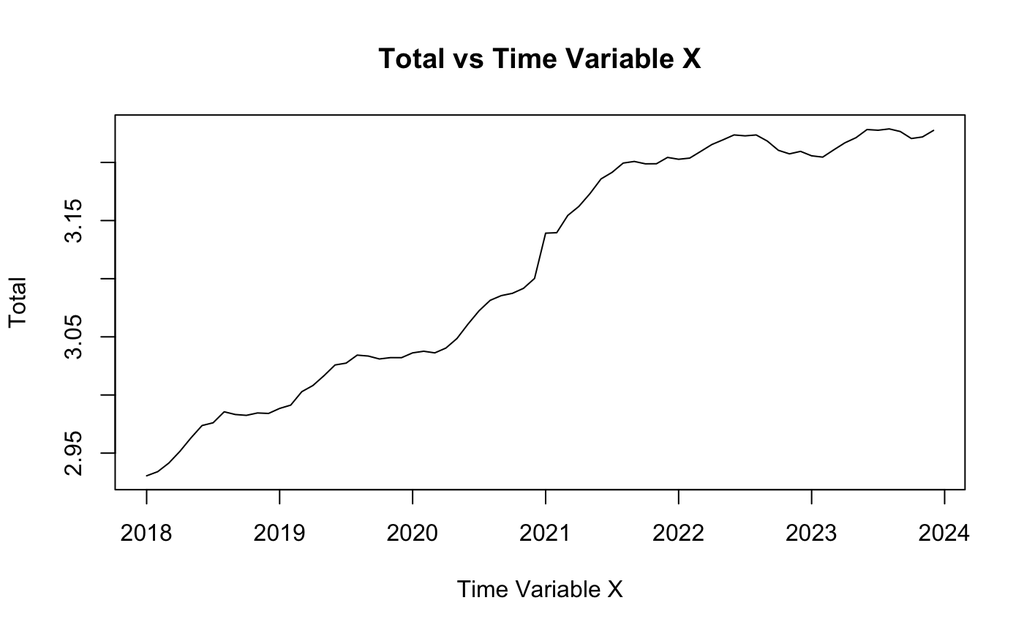

```r
# Plot training data vs x

variable_of_interest = Dtrain$total
plot(Dtrain$x, variable_of_interest, type = "l", xlab = "Time Variable X",
     ylab = "Total", main = "Total vs Time Variable X")
```

```r
# Basic statistics
cat("Start value (2018-01):", Dtrain$total[1], "\n")
```

```
Start value (2018-01): 2.930483
```

```r
cat("End value (2023-12):", tail(Dtrain$total, 1), "\n")
```

```
End value (2023-12): 3.227541
```

```r
cat("Total growth:", tail(Dtrain$total, 1) - Dtrain$total[1], "\n")
```

```
Total growth: 0.297058
```

```r
cat("Monthly observations:", nrow(Dtrain), "\n")
```

```
Monthly observations: 72
```

```r
cat("Average monthly growth:", mean(diff(Dtrain$total)), "\n")
```

```
Average monthly growth: 0.004183915
```

```r
cat("Annual growth rate:", mean(diff(Dtrain$total)) * 12, "\n")
```

```
Annual growth rate: 0.05020699
```

```r
# Linear trend fit (R² for predictability)
fit <- lm(total ~ x, data = Dtrain)
cat("Linear model R²:", round(summary(fit)$r.squared, 3), "\n")
```

```
Linear model R²: 0.934
```

```r
# Print results
print(fit)
```

```
Call:
lm(formula = total ~ x, data = Dtrain)

Coefficients:
(Intercept)            x
 -110.35543      0.05614
```

The training data plot shows a clear upward trend in total registered motor vehicles in Denmark from 2018 to approximately 2022 with slight downward hills in beginning of 2022 and also in the end of 2022 leading up to the start of 2023.

## 2. Linear trend model

```r
head(Dtrain[, c("x", "total")], 3)
```

|  | x | total |
| --- | --- | --- |
| 1 | 2018.000 | 2.930483 |
| 2 | 2018.083 | 2.934044 |
| 3 | 2018.167 | 2.941422 |

## 3. OLS - global linear trend model

# 3.1. Estimate the parameters θ1 and θ2 using the training set (call it the Ordinary Least Squares (OLS) estimates). Describe how you calculated the estimates.

```r
y <- Dtrain$total
X <- cbind(1, Dtrain$x)

thetahat <- solve(t(X) %*% X) %*% t(X) %*% y

thetahat
```

```
              [,1]
[1,] -110.35542809
[2,]    0.05614456
```

# 3.2

```r
# Step 1: Residuals
residuals <- y - X %*% thetahat

# Step 2: Estimate sigma^2 (residual variance)
n <- nrow(X)           # 72 observations
p <- ncol(X)           # 2 parameters
sigma2_hat <- sum(residuals^2) / (n - p)  # unbiased estimator

# Step 3: Variance-covariance matrix of thetahat
V_theta <- sigma2_hat * solve(t(X) %*% X)

# Step 4: Standard errors = sqrt(diag(V_theta))
se_theta1 <- sqrt(V_theta[1,1])  # σ̂_θ₁
se_theta2 <- sqrt(V_theta[2,2])  # σ̂_θ₂

se_theta1
```

```
[1] 3.593581
```

```r
se_theta2
```

```
[1] 0.001778156
```

```r
fitted_mean <- X %*% thetahat  # μ̂(x) for all training points

plot(Dtrain$x, Dtrain$total,
     pch = 16, col = "steelblue", cex = 0.8,
     xlab = "Time Variable x (fractional years)",
     ylab = "Total Registered Vehicles",
     main = "Observations and Estimated Mean")

lines(Dtrain$x, fitted_mean, col = "red", lwd = 2)
```

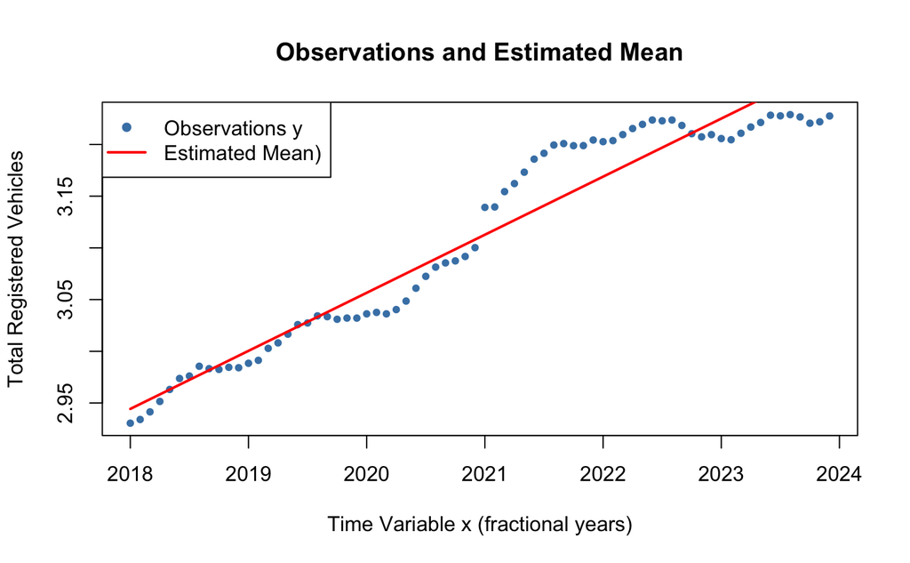

```r
# Legend
legend("topleft",
       legend = c("Observations y", "Estimated Mean)"),
       pch = c(16, NA),
       lty = c(NA, 1),
       col = c("steelblue", "red"),
       lwd = c(NA, 2))
```

# 3.3 Make a forecast for the test set, hence the following 12 months - i.e., compute predicted values

with corresponding prediction intervals for 2024-Jan to 2024-Dec. Present these values in a table.

```r
# Test set: 2024-Jan to Dec

# Create x
Dtest$x <- as.numeric(format(Dtest$time, "%Y")) +
            (as.numeric(format(Dtest$time, "%m")) - 1) / 12

X_test <- cbind(1, Dtest$x)

# Predictions + 95% prediction intervals
yhat_test <- X_test %*% thetahat

se_pred_test <- sqrt(sigma2_hat + diag(X_test %*% V_theta %*% t(X_test)))
t_crit <- qt(0.975, df = nrow(X) - ncol(X))  # 95% critical t-value

pred_int <- cbind(
  lower = yhat_test - t_crit * se_pred_test,
  upper = yhat_test + t_crit * se_pred_test
)

# Forecast table using Dtest months
forecast_table <- data.frame(
  Month = format(Dtest$time, "%b %Y"),
  x = round(Dtest$x, 3),
  Actual = round(Dtest$total, 3),
  Forecast = round(yhat_test, 3),
  `Lower 95%` = round(pred_int[,1], 3),
  `Upper 95%` = round(pred_int[,2], 3)
)
print(forecast_table, row.names = FALSE)
```

| Month | x | Actual | Forecast | Lower.95. | Upper.95. |
| --- | --- | --- | --- | --- | --- |
| Jan 2024 | 2024.000 | 3.224 | 3.281 | 3.228 | 3.335 |
| Feb 2024 | 2024.083 | 3.224 | 3.286 | 3.232 | 3.339 |
| Mar 2024 | 2024.167 | 3.231 | 3.291 | 3.237 | 3.344 |
| Apr 2024 | 2024.250 | 3.238 | 3.295 | 3.241 | 3.349 |
| May 2024 | 2024.333 | 3.245 | 3.300 | 3.246 | 3.354 |
| Jun 2024 | 2024.417 | 3.255 | 3.305 | 3.251 | 3.358 |
| Jul 2024 | 2024.500 | 3.255 | 3.309 | 3.255 | 3.363 |
| Aug 2024 | 2024.583 | 3.258 | 3.314 | 3.260 | 3.368 |
| Sep 2024 | 2024.667 | 3.257 | 3.319 | 3.264 | 3.373 |
| Oct 2024 | 2024.750 | 3.252 | 3.323 | 3.269 | 3.377 |

[output cut: 2 more lines]

# 3.4 Plot the fitted model together with the training data and the forecasted values (also plot the prediction intervals of the forecasted values).

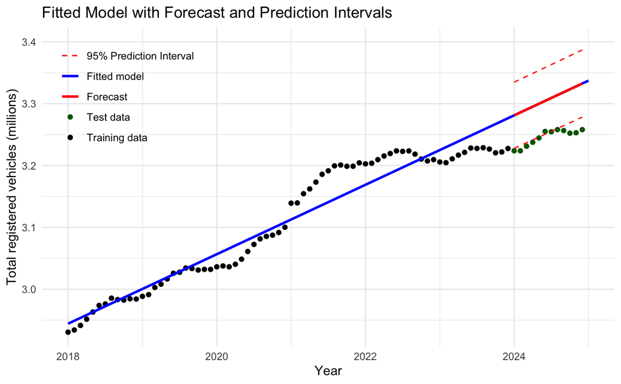

```r
# Order test data
ord <- order(Dtest$x)

# Dataframe for plot
Dpred <- data.frame(
  x = Dtest$x[ord],
  yhat = yhat_test[ord],
  lower = pred_int[ord, 1],
  upper = pred_int[ord, 2]
)


x_seq <- seq(min(c(Dtrain$x, Dtest$x)), 2025, length.out = 200)
Dfitted <- data.frame(
  x = x_seq,
  y = coef(fit)[1] + coef(fit)[2] * x_seq
)

ggplot() +
  geom_point(data = Dtrain,
             aes(x = x, y = total, color = "Training data")) +
  geom_point(data = Dtest,
             aes(x = x, y = total, color = "Test data")) +
  geom_line(data = Dfitted,
            aes(x = x, y = y, color = "Fitted model"),
            linewidth = 1) +
  geom_line(data = Dpred,
            aes(x = x, y = yhat, color = "Forecast"),
            linewidth = 1) +
  geom_line(data = Dpred,
            aes(x = x, y = lower, color = "95% Prediction Interval"),
            linetype = "dashed") +
  geom_line(data = Dpred,
            aes(x = x, y = upper, color = "95% Prediction Interval"),
            linetype = "dashed") +

  coord_cartesian(
    xlim = c(min(c(Dtrain$x, Dtest$x)), 2025),
    ylim = c(min(c(Dtrain$total, Dtest$total)), 3.4)) +

  scale_color_manual(
    name = "",
    values = c("Training data" = "black",
               "Test data" = "darkgreen",
               "Fitted model" = "blue",
               "Forecast" = "red",
               "95% Prediction Interval" = "red")) +

  labs(title = "Fitted Model with Forecast and Prediction Intervals",
       x = "Year",
       y = "Total registered vehicles (millions)") +

  theme_minimal() +
  theme(
    legend.position = "inside",
    legend.position.inside = c(0.02, 0.98),
    legend.justification = c(0, 0.9))
```

```r
X_train <- cbind(1, Dtrain$x)

# Predictions + 95% prediction intervals for training data
yhat_train <- X_train %*% thetahat

se_pred_train <- sqrt(sigma2_hat + diag(X_train %*% V_theta %*% t(X_train)))
t_crit_train <- qt(0.975, df = nrow(X) - ncol(X))  # 95% critical t-value
pred_int_train <- cbind(
  lower = yhat_train - t_crit_train * se_pred_train,
  upper = yhat_train + t_crit_train * se_pred_train
)
```

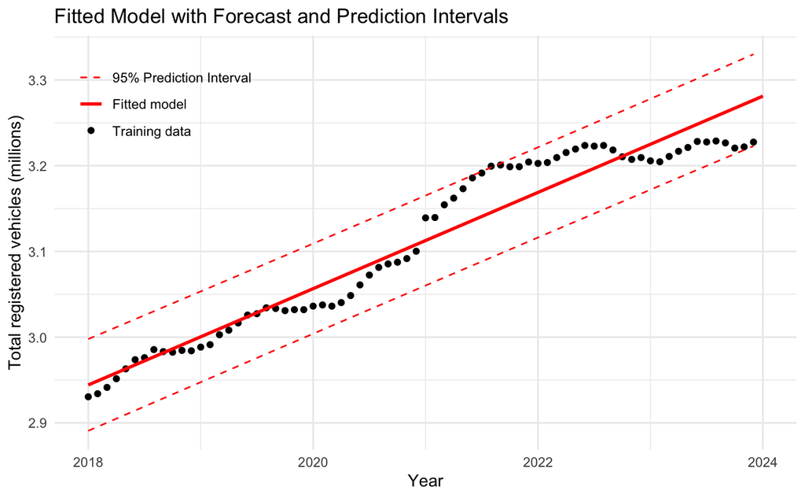

```r
# Order test data
ord_train <- order(Dtrain$x)

# Dataframe for plot
Dpred <- data.frame(
  x = Dtrain$x[ord_train],
  yhat = yhat_train[ord_train],
  lower = pred_int_train[ord_train, 1],
  upper = pred_int_train[ord_train, 2]
)


x_seq <- seq(min(c(Dtrain$x, Dtest$x)), 2024, length.out = 200)
Dfitted <- data.frame(
  x = x_seq,
  y = coef(fit)[1] + coef(fit)[2] * x_seq
)

ggplot() +
  geom_point(data = Dtrain,
             aes(x = x, y = total, color = "Training data")) +
  #geom_point(data = Dtest,
   #          aes(x = x, y = total, color = "Test data")) +
  geom_line(data = Dfitted,
            aes(x = x, y = y, color = "Fitted model"),
            linewidth = 1) +
  #geom_line(data = Dpred,
    #        aes(x = x, y = yhat, color = "Forecast"),
    #        linewidth = 1) +
  geom_line(data = Dpred,
            aes(x = x, y = lower, color = "95% Prediction Interval"),
            linetype = "dashed") +
  geom_line(data = Dpred,
            aes(x = x, y = upper, color = "95% Prediction Interval"),
            linetype = "dashed") +

  #coord_cartesian(
   # xlim = c(min(c(Dtrain$x, Dtest$x)), 2025),
    #ylim = c(min(c(Dtrain$total, Dtest$total)), 3.4)) +

  scale_color_manual(
    name = "",
    values = c("Training data" = "black",
               "Fitted model" = "red",
               "95% Prediction Interval" = "red")) +

  labs(title = "Fitted Model with Forecast and Prediction Intervals",
       x = "Year",
       y = "Total registered vehicles (millions)") +

  theme_minimal() +
  theme(
    legend.position = "inside",
    legend.position.inside = c(0.02, 0.98),
    legend.justification = c(0, 0.9))
```

# 3.6 Investigate the residuals of the model

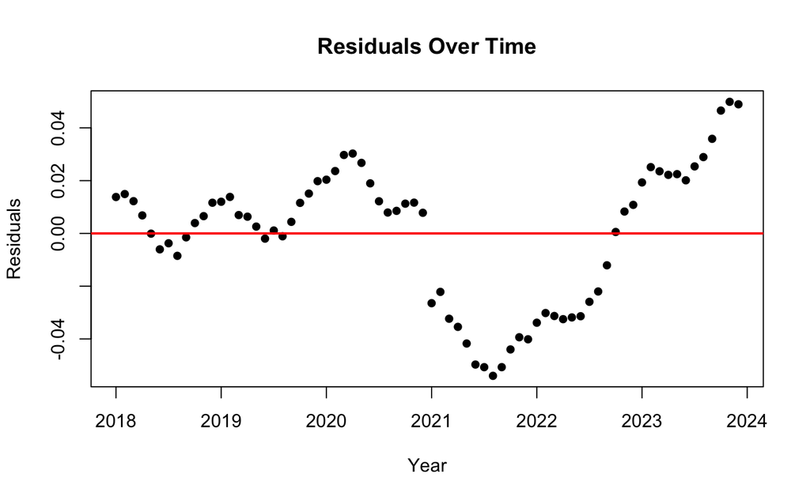

```r
residuals <- fitted_mean - Dtrain$total

plot(Dtrain$x, residuals,
     pch = 16,
     xlab = "Year",
     ylab = "Residuals",
     main = "Residuals Over Time")
abline(h = 0, col = "red", lwd = 2)
```

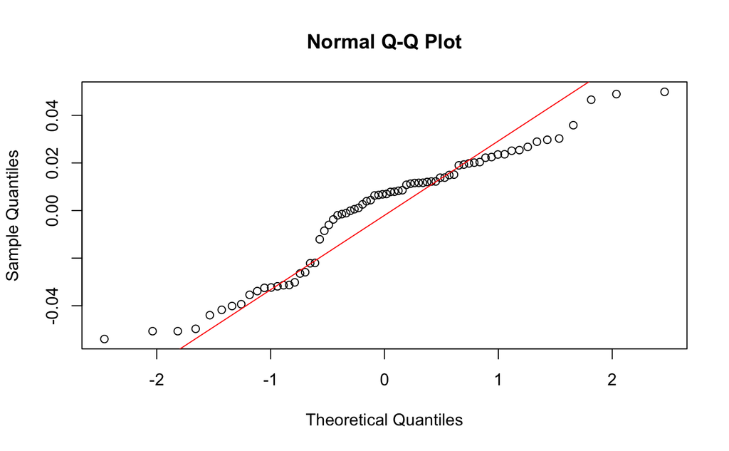

```r
qqnorm(residuals)
qqline(residuals, col = "red")
```

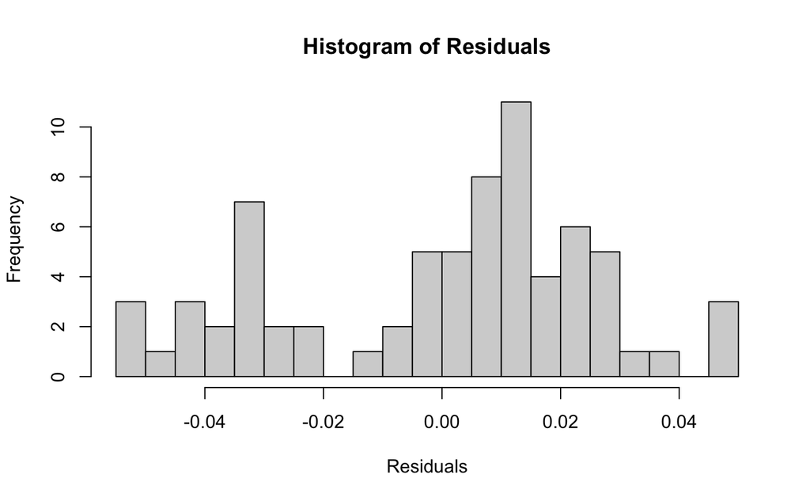

```r
hist(residuals,
     breaks = 15,
     main = "Histogram of Residuals",
     xlab = "Residuals")
```